# Quick and basic example of working with git

Here is the workflow I attempted to demonstrate during the Git Rganized workshop.

### 1. Create a repository on Git Hub.

#### i) Log in to [GitHub](https://github.com/login).

#### ii) Create a **new repository**.

Click **New repository** from the **+** dropdown menu on the top-right of the welcome screen next to your profile pic.

[figure not shown]

Fill in the fields of the **Create a new repository** page.

Choose whether you want your repos to be *public* or *private* (you can make private repositories public later). I recommend you click **Initialize this repository with a README** so you won’t forget to create a README later. I also recommend you add a **.gitignore** for the scripting language that you use. **Add a license** to allow other people to use your work. When you’re done, click the green **Create repository** button at the bottom of the screen.

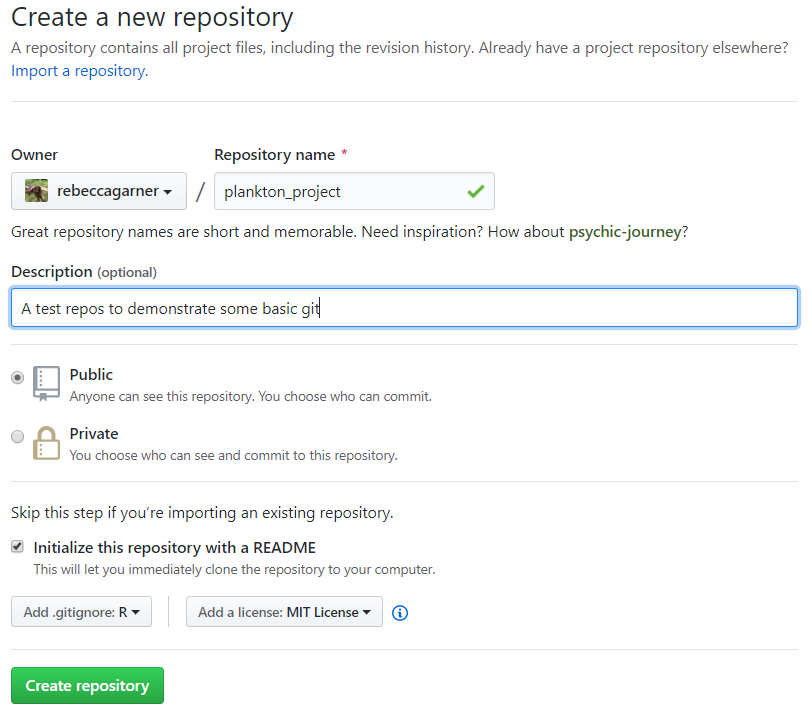

### 2. Clone your repository to your computer.

Your repository now exists as a *remote* repository on Git Hub. To be able to work on your repository from your local computer, you need to *clone* it to a location on your computer. Click on the green **Clone or download** button, highlight the URL in the box, and *copy* it.

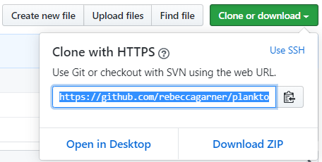

Open **Terminal** (on Mac) or **Git Bash** or **Command Prompt** (on Windows). Navigate to the folder where you want to store your repository. Use the command `git clone REPOSITORY_URL` to clone your repository (*paste* your copied URL instead of `REPOSITORY_URL`). In this example, I am cloning my plankton_project repository into my Documents folder.

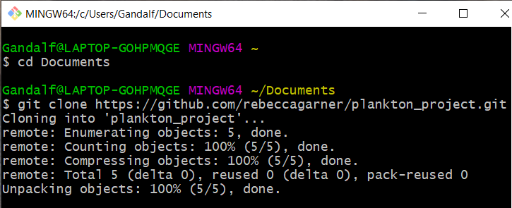

Optional: you can open the folder containing your cloned repository to *see* that it’s there.

[figure not shown]

`cd` into your repository and list all the files it contains.

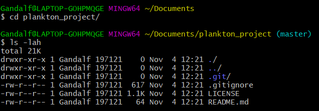

You’ll notice that the repository contains a folder named **.git/**. This **.git** folder contains the git version tracking information (so never delete the **.git** folder!)

#### A very short list of useful UNIX commands to help you navigate on the command line.

- `cd` changes the directory (directory = folder). `cd ..` moves up one directory. `cd /` moves up to the root directory.
- `pwd` tells you what directory you are currently in.
- `ls` lists the files in the current directory.`ls -lah` (which is `ls` with the argument `-lah`) lists all files including files with extensions starting with “.” (e.g. .git or .gitignore).

Note: UNIX commands have help information accessible by adding the argument `--help` after the command. Also note: UNIX commands are case-sensitive.